# Healthcare Data Analytics Portfolio

by Kevin Chen

January 2025

## Table of Contents

### Section 1: Introduction

##### a. Welcome

##### b. Scenario Background

##### c. Technical Skills Showcase

### Section 2: Exploring Data Sources

##### a. Official Government Data

##### b. Randomly Generated Data

### Section 3: Analysis Scenarios

##### Scenario I: Critical Member Identification

###### a. Setting the Stage

###### b. Ad Hoc Request: Identify members in active fire zones

###### c. In-Depth Analysis: Analyze member distribution in evacuation zones

###### d. Interactive Visualization: Member Details Dashboard

###### e. Key Findings

##### Scenario II: Structure Impact Analysis

###### a. Setting the Stage

###### b. Ad Hoc Request: Structure Damage and Member Impact Distribution

###### c. In-Depth Analysis: Cross-Incident Risk Assessment by Structure Type

###### d. Interactive Visualization: Preliminary Assessment Dashboard

###### e. Key Findings

##### Scenario III: Regional Coverage Analysis

###### a. Setting the Stage

###### b. Ad Hoc Request: Regional Premium Coverage Distribution

###### c. In-Depth Analysis: Regional Vulnerability and Coverage Risk Assessment

###### d. Interactive Visualization: City Data Explorer Dashboard

###### e. Key Findings

##### Scenario IV: Impact Scoring & Team Effectiveness

###### a. Setting the Stage

###### b. Ad Hoc Request: Priority Score Distribution Analysis

###### c. In-Depth Analysis: Team Workload and Effectiveness Analysis

###### d. Interactive Visualization: Impact & Response Analysis Dashboard

###### e. Key Findings

### Section 4: Other Projects & Websites

## 1. Introduction

### 1a. Welcome

##### Thank you for visiting my portfolio! I’m Kevin Chen, a Data Analyst in the healthcare insurance sector, specializing in transforming complex data into actionable insights. This portfolio highlights my work on a critical emergency response initiative, showcasing how advanced analytics—using SQL and Tableau—can enhance insurance member support during crises, with a focus on analyzing the impacts of the Los Angeles wildfires on insurance members.

### 1b. Scenario Background

##### This portfolio demonstrates advanced analytics capabilities in disaster recovery through a comprehensive analysis of healthcare member support following the wildfire in Los Angeles. Our healthcare insurance company launched a data-driven recovery program that integrates detailed damage assessment data (DINS - Damage Information Network System) with member information to provide targeted assistance to those most affected.

##### Through the integration of damage assessment data with member demographics and insurance information, we created a comprehensive support strategy that enables precise, needs-based assistance for our affected members during their recovery process. This approach showcases how combining governmental damage assessment data with internal member information can transform post-disaster recovery efforts in healthcare management.

### 1c. Technical Skills Showcase

##### This portfolio demonstrates my expertise in transforming complex disaster recovery data into actionable insights through three key technical areas:

#### **Advanced SQL Analysis**

##### I leverage sophisticated SQL querying techniques to analyze member impacts and optimize support strategies:

- Complex data integration using CTEs and window functions to merge DINS damage assessments with member data
- Geographic analysis through joins of structural damage data with member locations
- Member risk assessment using multi-dimensional analysis combining damage severity, coverage types, and member status
- Temporal pattern analysis tracking member status changes and premium distributions over time
- Status transition analysis using state matrices and flow tracking

#### **Interactive Tableau Dashboards**

##### My Tableau visualizations transform complex disaster recovery data into intuitive, actionable insights:

- Interactive damage severity maps showing member impact distribution
- Multi-layer visualizations combining property damage with insurance coverage analysis
- Dynamic member status tracking dashboards with drill-down capabilities
- Recovery timeline forecasting with milestone tracking
- Customizable filters for plan tiers and coverage types to support targeted assistance programs

#### **R Markdown Documentation**

##### The document you are currently reading demonstrates my R Markdown documentation capabilities:

- Professional structuring of analysis workflows and findings
- Clear organization with detailed table of contents
- Integration of technical content with business context
- Embedding of SQL queries and visualization examples
- Creation of stakeholder-friendly technical documentation
- Implementation of cross-referencing and clickable section shortcuts

##### Throughout this portfolio, you’ll see how these technical skills come together to support critical decision-making in post-disaster member support, demonstrating both analytical rigor and practical application in a real-world scenario. Each visualization, analysis, and section of this document is crafted to deliver clear, actionable insights for stakeholders managing disaster recovery efforts.

## 2. Exploring Data Sources

### 2a. Official Government Data

##### The following government datasets provides the foundation upon which the analysis can be built.

##### **CAL FIRE Data**

**Dataset**: DINS_2025_Palisades_Public_View.csv, DINS_2025_Eaton_Public_View.csv  
**Source**: California Department of Forestry and Fire Protection  
**URL**: https://data.ca.gov/dataset/cal-fire  
**Content**:

- Wildfire risk zones
- Geographic information
- Risk levels by area
- Property damage assessments
- Structural impact classifications

##### **LA County Evacuation Zones**

**Dataset**: Maximum_Extent_Evacuation_Zones.csv  
**Source**: Los Angeles County Open Data  
**URL**: https://data.lacounty.gov/  
**Content**:

- Emergency evacuation boundaries
- Zone classifications
- Geographic coordinates
- Population impact estimates
- Evacuation timeline data

### 2b. Randomly Generated Data

As a supplement to the government data, the insurance member dataset was randomly generated using a combination of AI (ChatGPT) and Python.

The following Python code was used to generate member Dataset:

```r
import pandas as pd
import numpy as np
import random
import string
from datetime import datetime, timedelta
from typing import List, Dict, Tuple

class InsuranceMemberGenerator:
    def __init__(self, seed: int = 42):
        try:
            self.seed = seed
            np.random.seed(seed)
            random.seed(seed)

            # Names Constants
            self.male_names = ['James', 'John', 'Robert', 'Michael', 'William', 'David', 'Richard', 'Joseph', 'Thomas', 'Charles', 'Christopher', 'Daniel', 'Matthew', 'Anthony', 'Donald', 'Mark', 'Paul', 'Steven', 'Andrew', 'Kenneth']
            self.female_names = ['Mary', 'Patricia', 'Jennifer', 'Linda', 'Elizabeth', 'Barbara', 'Susan', 'Jessica', 'Sarah', 'Karen', 'Lisa', 'Nancy', 'Betty', 'Margaret', 'Sandra', 'Ashley', 'Dorothy', 'Emma', 'Emily', 'Laura']
            self.last_names = self._generate_unique_last_names(4000)
            self.street_names = ['Main', 'Oak', 'Maple', 'Cedar', 'Pine', 'Elm', 'Washington', 'Lake', 'Hill', 'Park',
                                'River', 'Valley', 'Mountain', 'Spring', 'Sunset', 'Forest', 'Meadow', 'Ocean', 'Beach', 'Highland']

            # City and ZIP code distributions
            self.city_distribution = {'Los Angeles': 0.90, 'Malibu': 0.05, 'Santa Monica': 0.05}
            self.zip_codes = {
                'Los Angeles': {'90272': 0.60, '90290': 0.10, '90049': 0.10, '91356': 0.05, '91357': 0.05, '91316': 0.05, '91436': 0.05},
                'Malibu': {'90263': 0.40, '90264': 0.30, '90265': 0.30},
                'Santa Monica': {'90401': 0.20, '90402': 0.20, '90403': 0.20, '90404': 0.20, '90405': 0.20}
            }

            # Premium rates
            self.premium_rates = {
                ('Bronze', 'Individual'): 300,
                ('Bronze', 'Family'): 500,
                ('Silver', 'Individual'): 500,
                ('Silver', 'Family'): 700,
                ('Gold', 'Individual'): 700,
                ('Gold', 'Family'): 900,
                ('Platinum', 'Individual'): 900,
                ('Platinum', 'Family'): 1200
            }

        except Exception as e:
            raise RuntimeError(f"Failed to initialize generator: {str(e)}")

    def _generate_unique_last_names(self, count: int) -> List[str]:
        base_names = ['Smith', 'Johnson', 'Williams', 'Brown', 'Jones', 'Garcia', 'Miller', 'Davis', 'Rodriguez', 'Martinez']
        suffixes = ['', ' Jr', ' Sr', '-Smith', '-Jones', '-Williams', '-Davis', '-Miller', '-Brown', '-Garcia']

        names = []
        for name in base_names:
            for suffix in suffixes:
                names.append(f"{name}{suffix}")

        # Add more variations if needed
        while len(names) < count:
            name = random.choice(base_names)
            suffix = ''.join(random.choices(string.ascii_uppercase, k=2))
            names.append(f"{name}-{suffix}")

        return names[:count]

    def _generate_age_based_dob(self) -> datetime:
        age_ranges = {
            (12, 17): 0.05,
            (18, 24): 0.18,
            (25, 44): 0.35,
            (45, 64): 0.25,
            (65, 90): 0.17
        }

        # Select age range
        age_range = random.choices(list(age_ranges.keys()), weights=list(age_ranges.values()))[0]

        # Generate random age within range
        age = random.randint(age_range[0], age_range[1])

        # Calculate DOB
        today = datetime(2024, 1, 1)  # Fixed reference date
        dob = today - timedelta(days=age*365 + random.randint(0, 365))
        return dob

    def _generate_address(self) -> tuple:
        # Generate street address, city, and ZIP code
        street_num = random.randint(100, 9999)
        street_name = random.choice(self.street_names)

        # Select city based on distribution
        city = random.choices(list(self.city_distribution.keys()),
                            weights=list(self.city_distribution.values()))[0]

        # Select ZIP code based on city
        zip_code = random.choices(list(self.zip_codes[city].keys()),
                                weights=list(self.zip_codes[city].values()))[0]

        return (f"{street_num} {street_name} Street", city, zip_code)

    def generate_dataset(self, total_rows: int = 12041, member_rows: int = 3500) -> pd.DataFrame:

        # Generate the complete insurance member dataset
        if member_rows > total_rows - 1:
            raise ValueError("member_rows cannot exceed total_rows - 1")

        if total_rows < 2 or member_rows < 1:
            raise ValueError("total_rows must be at least 2 and member_rows must be positive")

        # Initialize DataFrame with row numbers
        df = pd.DataFrame({'RowNumber': range(1, total_rows + 1)})

        # Randomly select member rows (excluding row 1)
        member_indices = np.random.choice(range(2, total_rows + 1), size=member_rows, replace=False)

        # Generate member data
        member_data = []
        used_member_ids = set()
        used_addresses = set()

        for idx in member_indices:
            # Generate unique MemberID
            while True:
                member_id = f"LA1{str(random.randint(0, 999999)).zfill(6)}"
                if member_id not in used_member_ids:
                    used_member_ids.add(member_id)
                    break

            # Generate gender and name
            gender = random.choices(['M', 'F'], weights=[0.49, 0.51])[0]
            first_name = random.choice(self.male_names if gender == 'M' else self.female_names)
            last_name = random.choice(self.last_names)

            # Generate dates
            dob = self._generate_age_based_dob()

            # Calculate enrollment date range
            min_enrollment_date = max(
                datetime(2000, 1, 1),  # Not earlier than 2000
                dob + timedelta(days=18*365)  # Must be at least 18 years after DOB
            )
            max_enrollment_date = datetime(2024, 12, 31)

            # Ensure valid enrollment date range
            if min_enrollment_date >= max_enrollment_date:
                min_enrollment_date = max_enrollment_date - timedelta(days=365)

            # Generate enrollment date
            days_range = (max_enrollment_date - min_enrollment_date).days
            enrollment_date = min_enrollment_date + timedelta(days=random.randint(0, max(0, days_range)))

            # Generate status change date
            max_status_date = datetime(2024, 12, 31)
            days_until_max = (max_status_date - enrollment_date).days

            if days_until_max <= 0:
                # If enrollment is on or after max date, use enrollment date
                status_change_date = enrollment_date
            elif days_until_max == 1:
                # If only one day left, use either enrollment date or next day
                status_change_date = enrollment_date + timedelta(days=random.choice([0, 1]))
            else:
                # Normal case: random date between enrollment and max date
                status_change_date = enrollment_date + timedelta(
                    days=random.randint(0, days_until_max)
                )

            # Generate address
            while True:
                address = self._generate_address()
                if address[0] not in used_addresses:
                    used_addresses.add(address[0])
                    break

            # Generate plan details
            plan_tier = random.choices(['Bronze', 'Silver', 'Gold', 'Platinum'],
                                    weights=[0.40, 0.30, 0.20, 0.10])[0]
            coverage_type = random.choices(['Individual', 'Family'],
                                        weights=[0.65, 0.35])[0]
            monthly_premium = self.premium_rates[(plan_tier, coverage_type)]

            # Generate status
            member_status = random.choices(['Active', 'Terminated', 'Suspended', 'Pending'],
                                        weights=[0.65, 0.20, 0.10, 0.05])[0]

            member_data.append({
                'RowNumber': idx,
                'MemberID': member_id,
                'FirstName': first_name,
                'LastName': last_name,
                'DOB': dob,
                'Gender': gender,
                'Street': address[0],
                'City': address[1],
                'State': 'CA',
                'ZipCode': address[2],
                'EnrollmentDate': enrollment_date,
                'PlanTier': plan_tier,
                'CoverageType': coverage_type,
                'MonthlyPremium': monthly_premium,
                'MemberStatus': member_status,
                'LastStatusChangeDate': status_change_date
            })

        # Create member DataFrame
        member_df = pd.DataFrame(member_data)

        # Merge with main DataFrame
        df = df.merge(member_df, how='left', on='RowNumber')

        return df

    def save_dataset(self, df: pd.DataFrame, filename: str):
        df.to_csv(filename, index=False)

if __name__ == "__main__":
    generator = InsuranceMemberGenerator(seed=42)
    df = generator.generate_dataset()
    generator.save_dataset(df, "insurance_members.csv")
```

## 3. Analysis Scenarios

### Scenario I: Critical Member Identification

#### **A. Setting the Stage**

##### When wildfires swept through Los Angeles County, our Emergency Response Team faced an urgent challenge: How do we quickly identify and reach our most vulnerable members? With thousands potentially affected, we needed to rapidly assess who was in immediate danger and required priority assistance.

#### **B. Ad Hoc Request**

##### Which active members are currently located in the Palisades fire zone and need immediate contact?

```sql
SELECT
    MemberID,
    CAST(FirstName AS VARCHAR) || ' ' || CAST(LastName AS VARCHAR) as FullName,
    City,
    ZipCode,
    IncidentName,
    MemberStatus
FROM Tableau_Dataset
WHERE IncidentName = 'PALISADES'
    AND MemberStatus = 'Active'
ORDER BY ZipCode
LIMIT 5;
```

5 records

| MemberID | FullName | City | ZipCode | IncidentName | MemberStatus |
| --- | --- | --- | --- | --- | --- |
| LA1874251 | Patricia Martinez | Los Angeles | 90049 | PALISADES | Active |
| LA1642367 | Sandra Brown | Los Angeles | 90049 | PALISADES | Active |
| LA1991747 | Jessica Brown | Los Angeles | 90049 | PALISADES | Active |
| LA1514476 | Nancy Miller | Los Angeles | 90049 | PALISADES | Active |
| LA1811735 | Michael Miller | Los Angeles | 90049 | PALISADES | Active |

#### **C. In-Depth Analysis**

##### How are our members distributed across evacuation zones, and where should we focus our immediate emergency response efforts?

```sql
WITH MemberLocation AS (
    SELECT
        City,
        ZipCode,
        IncidentName,
        COUNT(*) as TotalMembers,
        COUNT(CASE WHEN MemberStatus = 'Active' THEN 1 END) as ActiveMembers,
        COUNT(CASE WHEN CoverageType = 'Family' THEN 1 END) as FamilyPlans
    FROM Tableau_Dataset
    WHERE ZipCode IS NOT NULL
        AND IncidentName IN ('PALISADES', 'EATON')
    GROUP BY City, ZipCode, IncidentName
)
SELECT
    IncidentName,
    City,
    ZipCode,
    TotalMembers,
    ActiveMembers,
    FamilyPlans,
    ROUND(CAST(ActiveMembers AS FLOAT) / NULLIF(TotalMembers, 0), 4) * 100 AS ActiveMemberPercentage
FROM MemberLocation
ORDER BY TotalMembers DESC
LIMIT 5;
```

5 records

| IncidentName | City | ZipCode | TotalMembers | ActiveMembers | FamilyPlans | ActiveMemberPercentage |
| --- | --- | --- | --- | --- | --- | --- |
| EATON | Altadena | 91001 | 2417 | 1693 | 824 | 70.05 |
| PALISADES | Los Angeles | 90272 | 1885 | 1236 | 667 | 65.57 |
| EATON | La Canada Flintridge | 91011 | 518 | 381 | 181 | 73.55 |
| EATON | Sierra Madre | 91024 | 512 | 364 | 194 | 71.09 |
| PALISADES | Los Angeles | 90290 | 312 | 204 | 123 | 65.38 |

#### **D. Interactive Visualization**

##### Member Details Dashboard

**[Click to open:](https://public.tableau.com/views/11_LA_Wildfire_Response/Page1?:language=en-US&publish=yes&:sid=&:redirect=auth&:display_count=n&:origin=viz_share_link)**

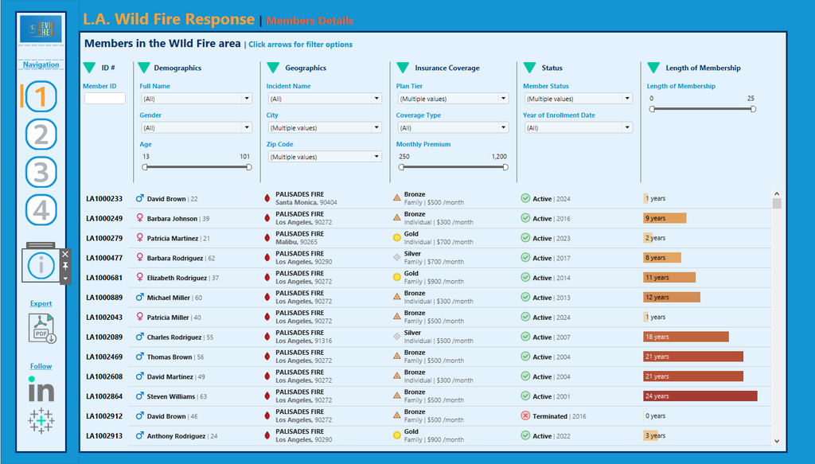

#### **E. Key Findings**

##### **3. Member Status Analysis**

- Active members constitute majority in affected areas
- Notable presence of long-term members (>10 years)
- Family coverage represents approximately 35% of affected members

##### **4. Coverage Distribution**

- Active member rates range from 65-73% across affected zones
- Family plans show significant presence in high-impact areas

### Scenario II: Structure Impact Analysis

#### **A. Setting the Stage**

##### The initial damage reports came in fragmented and unclear. We needed to understand not just where the fires were, but how different types of structures were affected. Our Emergency Response Team required a clear picture: which areas had the most severe structural damage, and where were our members most at risk?

#### **B. Ad Hoc Request**

##### What is the current distribution of structural damage across different building types in the Palisades Fire area, and how many members are affected in each category?

```sql
SELECT
    StructureType,
    Damage,
    COUNT(*) as structure_count,
    COUNT(DISTINCT MemberID) as affected_members
FROM Tableau_Dataset
WHERE IncidentName = 'PALISADES'
    AND StructureType IS NOT NULL
GROUP BY StructureType, Damage
ORDER BY structure_count DESC
LIMIT 5;
```

5 records

| Structuretype | Damage | structure_count | affected_members |
| --- | --- | --- | --- |
| Single Family Residence Multi Story | Destroyed (>50%) | 2734 | 820 |
| Single Family Residence Single Story | Destroyed (>50%) | 2323 | 708 |
| Single Family Residence Multi Story | No Damage | 2144 | 616 |
| Utility Misc Structure | Destroyed (>50%) | 1114 | 304 |
| Single Family Residence Single Story | No Damage | 1044 | 280 |

#### **C. In-Depth Analysis**

##### How do structure types correlate with damage severity, member impact, and financial exposure across both fire incidents, and which areas represent the highest risk for our insured members?

```sql
WITH damage_metrics AS (
    SELECT
        IncidentName,
        StructureType,
        Damage,
        -- Count structures
        COUNT(*) as structure_count,
        -- Count affected members
        COUNT(DISTINCT MemberID) as member_count,
        -- Calculate damage severity weight
        SUM(CASE
            WHEN Damage = 'Destroyed' THEN 5
            WHEN Damage = 'Major' THEN 4
            WHEN Damage = 'Minor' THEN 3
            WHEN Damage = 'Affected' THEN 2
            WHEN Damage = 'Inaccessible' THEN 1
            ELSE 0
        END) as damage_severity_score
    FROM Tableau_Dataset
    WHERE IncidentName IN ('PALISADES', 'EATON')
        AND StructureType IS NOT NULL
    GROUP BY IncidentName, StructureType, Damage
),
incident_summary AS (
    SELECT
        IncidentName,
        StructureType,
        SUM(structure_count) as total_structures,
        SUM(member_count) as total_affected_members,
        SUM(damage_severity_score) as total_damage_score
    FROM damage_metrics
    GROUP BY IncidentName, StructureType
)
SELECT
    i.*,
    -- Calculate risk priority
    DENSE_RANK() OVER (
        PARTITION BY IncidentName
        ORDER BY total_damage_score DESC
    ) as risk_priority,
    -- Calculate impact priority
    DENSE_RANK() OVER (
        PARTITION BY IncidentName
        ORDER BY total_affected_members DESC
    ) as impact_priority
FROM incident_summary i
ORDER BY
    total_damage_score DESC,
    impact_priority
LIMIT 5;
```

5 records

| IncidentName | StructureType | total_structures | total_affected_members | total_damage_score | risk_priority | impact_priority |
| --- | --- | --- | --- | --- | --- | --- |
| EATON | Single Family Residence Single Story | 9410 | 2574 | 21 | 1 | 1 |
| EATON | Single Family Residence Multi Story | 2457 | 672 | 10 | 2 | 3 |
| EATON | Utility Misc Structure | 5685 | 1520 | 9 | 3 | 2 |
| PALISADES | Single Family Residence Multi Story | 5350 | 1575 | 0 | 1 | 1 |
| PALISADES | Single Family Residence Single Story | 3682 | 1087 | 0 | 1 | 2 |

#### **D. Interactive Visualization**

##### Preliminary Assessment Dashboard

**[Click to open:](https://public.tableau.com/views/11_LA_Wildfire_Response/Page2?:language=en-US&publish=yes&:sid=&:redirect=auth&:display_count=n&:origin=viz_share_link)**

[figure not shown]

#### **E. Key Findings**

##### **2. Damage Distribution Pattern**

- Residential structures show a binary damage pattern: either severe damage (destroyed/major) or minimal impact, with few intermediate cases.
- This pattern suggests clear impact zone boundaries, enabling more targeted response strategies.

##### **4. Geographic Risk Stratification**

- Clear correlation between evacuation zones and structure damage levels.
- Evacuation warnings form distinct buffer zones around areas with the highest structural damage, providing a predictive indicator for potential damage spread.

### Scenario III: Regional Coverage Analysis

#### **A. Setting the Stage**

##### As response teams mobilized, a critical question emerged: were we seeing patterns in how the fires affected different communities? Understanding the demographic and geographic distribution of our affected members became crucial for tailoring our support services and allocating resources effectively.

#### **B. Ad Hoc Request**

##### What is the distribution of members and their insurance tiers across different cities, and which areas show the highest concentration of premium plans (Gold/Platinum)?

```sql
SELECT
    City,
    COUNT(DISTINCT MemberID) as total_members,
    SUM(CASE WHEN PlanTier IN ('Gold', 'Platinum') THEN 1 ELSE 0 END) as premium_plan_count,
    ROUND(CAST(AVG(CAST(MonthlyPremium AS FLOAT)) AS NUMERIC), 2) as avg_monthly_premium,
    COUNT(DISTINCT CASE WHEN CoverageType = 'Family' THEN MemberID END) as family_coverage_count
FROM Tableau_Dataset
WHERE MemberID IS NOT NULL
    AND City IS NOT NULL
GROUP BY City
ORDER BY total_members DESC
LIMIT 5;
```

5 records

| City | total_members | premium_plan_count | avg_monthly_premium | family_coverage_count |
| --- | --- | --- | --- | --- |
| Los Angeles | 3145 | 935 | 573.42 | 1134 |
| Altadena | 2417 | 740 | 526.00 | 824 |
| Pasadena | 1025 | 326 | 530.98 | 370 |
| Arcadia | 528 | 172 | 536.36 | 187 |
| La Canada Flintridge | 518 | 149 | 516.22 | 181 |

#### **C. In-Depth Analysis**

##### How does the impact of the wildfires on insurance members vary across different cities in terms of member demographics, plan types, premium rates, and property damage?

```sql
WITH age_categorized AS (
    SELECT
        City,
        CASE
            WHEN strftime('%Y', 'now') - strftime('%Y', DOB) < 18 THEN '1-17'
            WHEN strftime('%Y', 'now') - strftime('%Y', DOB) < 25 THEN '18-24'
            WHEN strftime('%Y', 'now') - strftime('%Y', DOB) < 45 THEN '25-44'
            WHEN strftime('%Y', 'now') - strftime('%Y', DOB) < 65 THEN '45-64'
            ELSE '65+'
        END as age_group,
        PlanTier,
        CoverageType,
        CAST(MonthlyPremium AS INTEGER) as monthly_premium,
        Damage,
        MemberStatus
    FROM Tableau_Dataset
    WHERE City IS NOT NULL
)
SELECT
    City,
    COUNT(*) as total_members,
    SUM(CASE WHEN age_group = '65+' THEN 1 ELSE 0 END) as elderly_count,
    SUM(CASE WHEN age_group = '1-17' THEN 1 ELSE 0 END) as minor_count,
    SUM(CASE WHEN PlanTier IN ('Gold', 'Platinum') THEN 1 ELSE 0 END) as premium_plan_count,
    SUM(CASE WHEN CoverageType = 'Family' THEN 1 ELSE 0 END) as family_coverage_count,
    SUM(CASE WHEN Damage LIKE 'Destroyed%' THEN 1 ELSE 0 END) as severe_damage_count,
    ROUND(AVG(monthly_premium), 2) as avg_premium,
    SUM(CASE WHEN MemberStatus = 'Active' THEN 1 ELSE 0 END) as active_members,
    ROUND(CAST(SUM(CASE WHEN age_group IN ('1-17', '65+') THEN 1 ELSE 0 END) * 100.0 / COUNT(*) AS FLOAT), 2) as vulnerable_population_pct
FROM age_categorized
GROUP BY City
HAVING SUM(CASE WHEN MemberStatus = 'Active' THEN 1 ELSE 0 END) > 0
ORDER BY total_members DESC
LIMIT 5;
```

5 records

| City | total_members | elderly_count | minor_count | premium_plan_count | family_coverage_count | severe_damage_count | avg_premium | active_members | vulnerable_population_pct |
| --- | --- | --- | --- | --- | --- | --- | --- | --- | --- |
| Los Angeles | 3145 | 592 | 95 | 935 | 1134 | 1814 | 573.42 | 2059 | 21.84 |
| Altadena | 2417 | 420 | 111 | 740 | 824 | 1230 | 526.00 | 1693 | 21.97 |
| Pasadena | 1025 | 177 | 47 | 326 | 370 | 526 | 530.98 | 729 | 21.85 |
| Arcadia | 528 | 86 | 25 | 172 | 187 | 260 | 536.36 | 372 | 21.02 |
| La Canada Flintridge | 518 | 84 | 28 | 149 | 181 | 270 | 516.22 | 381 | 21.62 |

#### **D. Interactive Visualization**

##### City Data Explorer Dashboard

**[Click to open:](https://public.tableau.com/views/11_LA_Wildfire_Response/Page3?:language=en-US&:sid=&:redirect=auth&:display_count=n&:origin=viz_share_link)**

[figure not shown]

#### **E. Key Findings**

##### **2. Demographic Vulnerability Consistency**

- Age distribution reveals: Largest segment: Ages 25-44 (36%), Second largest: Ages 45-64 (26%), Significant elderly population: Ages 65+ (18%)
- Remarkably uniform vulnerable population percentage (21-22%) across all analyzed cities
- Consistent vulnerability metrics enable standardized support protocols

##### **3. Coverage and Financial Insights**

- Premium plan adoption shows regional variation: Los Angeles: 29.7% premium plan adoption (935 members), Altadena: 30.6% premium plan adoption (740 members)
- Higher average premiums in Los Angeles ($573.42) compared to other cities
- Family coverage is significant in Los Angeles (1,134 families, 36% of members)
- High premium plan adoption indicates financial capacity for enhanced services

### Scenario IV: Priority Impact & Team Distribution

#### **A. Setting the Stage**

##### Our response teams were stretched thin across multiple affected areas. We needed a systematic way to assign cases and measure intervention effectiveness. How could we ensure our most vulnerable members received appropriate support while maintaining sustainable workloads for our teams?

#### **B. Ad Hoc Request**

##### What is the initial distribution of priority scores across different age groups and coverage types, and how does this affect our team workload allocation?

```sql
WITH priority_scoring AS (
    SELECT
        MemberID,
        CASE
            WHEN CAST(strftime('%Y', '2025') - strftime('%Y', DOB) AS INTEGER) < 18 THEN 1
            WHEN CAST(strftime('%Y', '2025') - strftime('%Y', DOB) AS INTEGER) >= 65 THEN 2
            ELSE 0
        END AS age_points,
        CASE WHEN CoverageType = 'Family' THEN 2 ELSE 0 END AS coverage_points,
        CASE WHEN PlanTier IN ('Platinum', 'Gold') THEN 1 ELSE 0 END AS tier_points
    FROM Tableau_Dataset
    WHERE MemberID IS NOT NULL
)
SELECT
    (age_points + coverage_points + tier_points + 1) AS priority_score,
    COUNT(*) as member_count,
    ROUND(COUNT(*) * 100.0 / SUM(COUNT(*)) OVER (), 2) as percentage,
    CASE
        WHEN (age_points + coverage_points + tier_points + 1) >= 5 THEN 'Team Alpha'
        WHEN (age_points + coverage_points + tier_points + 1) = 4 THEN 'Team Beta'
        WHEN (age_points + coverage_points + tier_points + 1) = 3 THEN 'Team Gamma'
        ELSE 'Team Delta'
    END as assigned_team
FROM priority_scoring
GROUP BY priority_score
ORDER BY priority_score DESC;
```

5 records

| priority_score | member_count | percentage | assigned_team |
| --- | --- | --- | --- |
| 5 | 913 | 3.00 | Team Alpha |
| 4 | 2087 | 6.85 | Team Beta |
| 3 | 1683 | 5.53 | Team Gamma |
| 2 | 3817 | 12.53 | Team Delta |
| 1 | 21961 | 72.10 | Team Delta |

#### **C. In-Depth Analysis**

##### How effectively are our response teams handling their assigned workloads based on member priority scores, and are there any significant imbalances in case complexity or resource distribution that need to be addressed?

```sql
WITH member_scoring AS (
    SELECT DISTINCT  -- Add DISTINCT to ensure unique member records
        MemberID,
        CoverageType,
        PlanTier,
        MemberStatus,
        Damage,
        MonthlyPremium,
        CASE
            WHEN CAST(strftime('%Y', '2025') - strftime('%Y', DOB) AS INTEGER) < 18 THEN 1
            WHEN CAST(strftime('%Y', '2025') - strftime('%Y', DOB) AS INTEGER) >= 65 THEN 2
            ELSE 0
        END AS age_points,
        CASE WHEN CoverageType = 'Family' THEN 2 ELSE 0 END AS coverage_points,
        CASE WHEN PlanTier IN ('Platinum', 'Gold') THEN 1 ELSE 0 END AS tier_points
    FROM Tableau_Dataset
    WHERE MemberID IS NOT NULL
),
priority_assignment AS (
    SELECT
        *,
        (age_points + coverage_points + tier_points + 1) AS priority_score,
        CASE
            WHEN (age_points + coverage_points + tier_points + 1) >= 5 THEN 'Team Alpha'
            WHEN (age_points + coverage_points + tier_points + 1) = 4 THEN 'Team Beta'
            WHEN (age_points + coverage_points + tier_points + 1) = 3 THEN 'Team Gamma'
            ELSE 'Team Delta'
        END AS assigned_team
    FROM member_scoring
)
SELECT
    assigned_team,
    COUNT(DISTINCT MemberID) as total_cases,  -- Count distinct members
    ROUND(AVG(priority_score), 2) as avg_priority_score,
    SUM(CASE WHEN Damage IN ('Destroyed', 'Major', 'Destroyed ', 'Major ')
             OR Damage LIKE '%Destroyed%'
             OR Damage LIKE '%Major%' THEN 1 ELSE 0 END) as high_damage_cases,
    SUM(CASE WHEN CoverageType = 'Family' THEN 1 ELSE 0 END) as family_cases,
    SUM(CASE WHEN priority_score >= 4 THEN 1 END) as high_priority_cases,
    ROUND(COUNT(DISTINCT MemberID) * 100.0 / SUM(COUNT(DISTINCT MemberID)) OVER (), 2) as workload_percentage,
    ROUND(SUM(MonthlyPremium), 2) as total_monthly_premium
FROM priority_assignment
GROUP BY assigned_team
ORDER BY avg_priority_score DESC;
```

4 records

| assigned_team | total_cases | avg_priority_score | high_damage_cases | family_cases | high_priority_cases | workload_percentage | total_monthly_premium |
| --- | --- | --- | --- | --- | --- | --- | --- |
| Team Alpha | 913 | 5 | 493 | 913 | 913 | 10.74 | 887350 |
| Team Beta | 2087 | 4 | 1112 | 2087 | 2087 | 24.55 | 1158050 |
| Team Gamma | 1683 | 3 | 923 | 0 | NA | 19.80 | 1240850 |
| Team Delta | 3818 | 2 | 2065 | 0 | NA | 44.91 | 1365950 |

#### **D. Interactive Visualization**

##### Impact & Response Analysis Dashboard

**[Click to open:](https://public.tableau.com/views/11_LA_Wildfire_Response/Page4?:language=en-US&:sid=&:redirect=auth&:display_count=n&:origin=viz_share_link)**

[figure not shown]

#### **E. Key Findings**

##### **2. Family Coverage Concentration**

- All family coverage cases are handled by the more experienced teams (Alpha and Beta)
- This aligns with the higher priority scores given to family coverage (+2 points)

##### **3. High-Priority Case Management**

- Teams Alpha and Beta handle all cases with priority scores 4 and above
- This ensures the most complex cases are managed by the most experienced teams

##### **4. Resource Allocation Efficiency**

- Despite handling fewer cases, Teams Alpha and Beta manage higher-complexity situations
- Team Delta handles the highest volume but less complex cases, matching their resource capacity

## 4. Other Projects & Websites

#### I appreciate you taking the time to explore my work and experience with Tableau & SQL. If you’d like to learn more about my professional journey or connect, feel free to visit my LinkedIn profile. Additionally, you can check out my other projects and resources to see how I apply my skills across different domains. Thank you again for your interest, and I look forward to connecting with you!

#### [LinkedIn](https://www.linkedin.com/in/kevch27) | [Credly Badges](https://www.credly.com/users/kevin-chen.8bcacc53/badges)

#### [Tableau Portfolio](https://public.tableau.com/app/profile/kevch27)

##### My Tableau portfolio highlights my learning journey, with each project progressively becoming more advanced as I continue to deepen my expertise in Tableau.

#### [Maven Website](https://mavenanalytics.io/project/6664)

##### Here, you’ll find my capstone project for completing the Google Data Analytics Professional Certificate.